# Warmup 2: Data Visualization

```r
library(dplyr)
```

```r
library(ggplot2)
library(lubridate)
```

## 1. Graphic from FiveThirtyEight

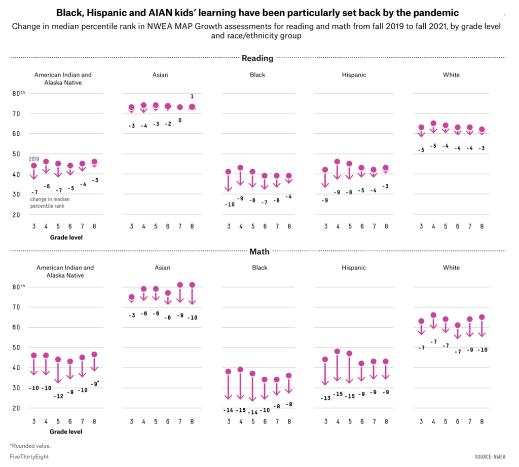

### b) What color scheme (if any) is being used in the graphic?

The vectors which represents the change in median percentile rank from fall 2019 to fall 2021 is represented as a color “pink.”

### c) Taking into account the so-called “Data-Ink ratio”, explain whether the graphic seems to be maximizing this ratio or not.

The graphic seems to be maximizing the “Data-Ink ratio” because the data is showing the change in median percentile rank from fall 2019 to fall 2021 using vectors to emphasize the difference by different grade level and race groups. It does not contain any unnecessary non-data ink and emphasized the most important data ink.

### d) Describe the things that you find interesting about the chosen graphic

First, when I skimmed this graphic the first thing it came to me was the pink vectors pointing down. I’ve never seen a graph like this before that uses a vector to emphasize the difference in percentile. By using vectors, it was easily interpreted that the percentile ranks for almost every grade levels and race went down since COVID-19 happened.

### e)screenshot

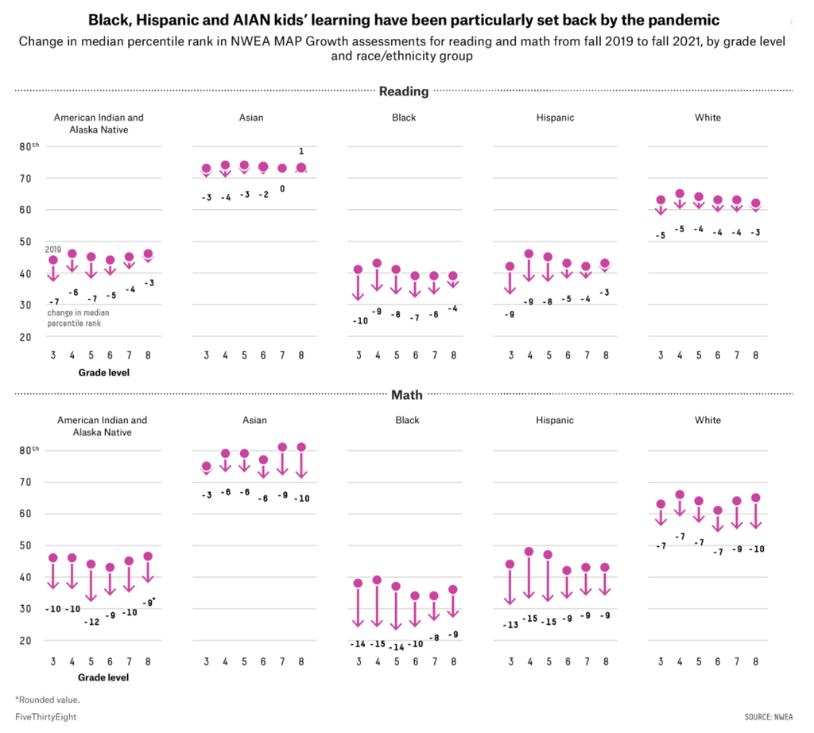

### f) link & authors

https://fivethirtyeight.com/features/covid-19-has-left-millions-of-students-behind-now-what/

By Maggie Koerth

Graphics by Simran Parwani

## 2. Instagram Graph

### 2.1) Graphic’s Assessment

#### Provide an assessment of the above bar-chart, describing the good and the bad about this data visualization.

The good thing about this data visualization is that it is easy to interpret. It is clear that the x-axis is representing the days of the week. It is also clear that the most time spent day is Saturday which has the highest height.  
The bad thing is that there is no y-axis which represents the time spent. We aren’t able to make any numerical interpretation just by looking at this graph.

### 2.2) Replicate Instagram’s Bar-chart

#### The following table contains the data of the bar-chart (minutes spent on Instagram’s app by day):

```r
instagram <- data.frame(Day = c("Fri","Sat","Sun","Mon","Tue","Wed","Thu"), Time = c(40,70,40,65,62,52,48))
instagram
```

```
##   Day Time
## 1 Fri   40
## 2 Sat   70
## 3 Sun   40
## 4 Mon   65
## 5 Tue   62
## 6 Wed   52
## 7 Thu   48
```

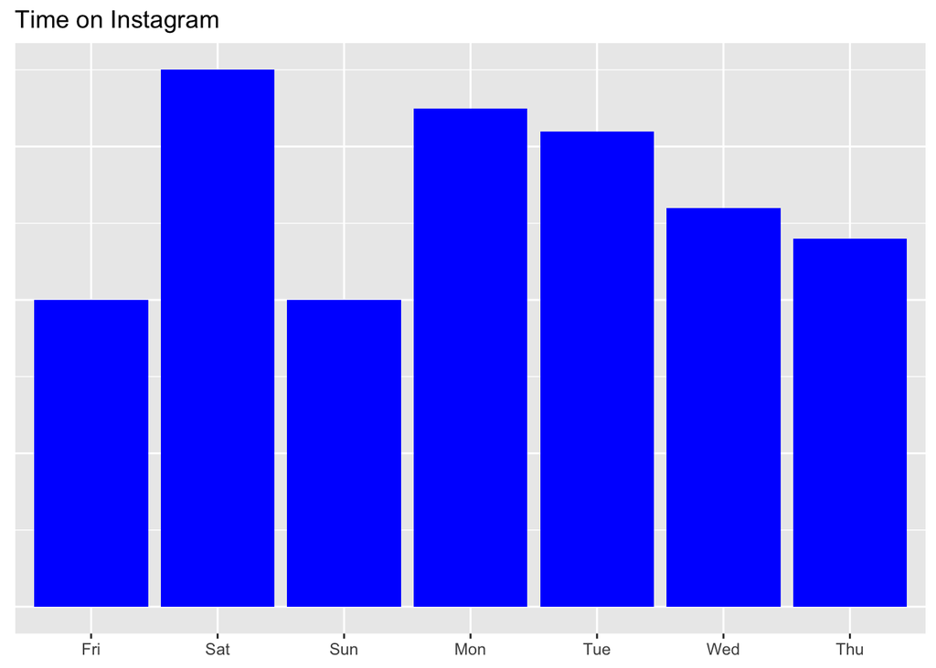

```r
ggplot(data = instagram, aes(x = Day, y = Time)) + geom_bar(stat="identity", fill ="blue")+
  theme(axis.text.y=element_blank(),
        axis.ticks.y=element_blank(),
        axis.title.y = element_blank(),
        axis.title.x= element_blank()
        ) + labs(title = "Time on Instagram") +scale_x_discrete(limits=instagram$Day)
```

### 2.3) Improved Alternative Instagram Visualization

#### Write code to generate a graphic that improves the visualization of the original Instagram bar-chart.Also, provide a description/explanation of how your proposal improves the original chart.

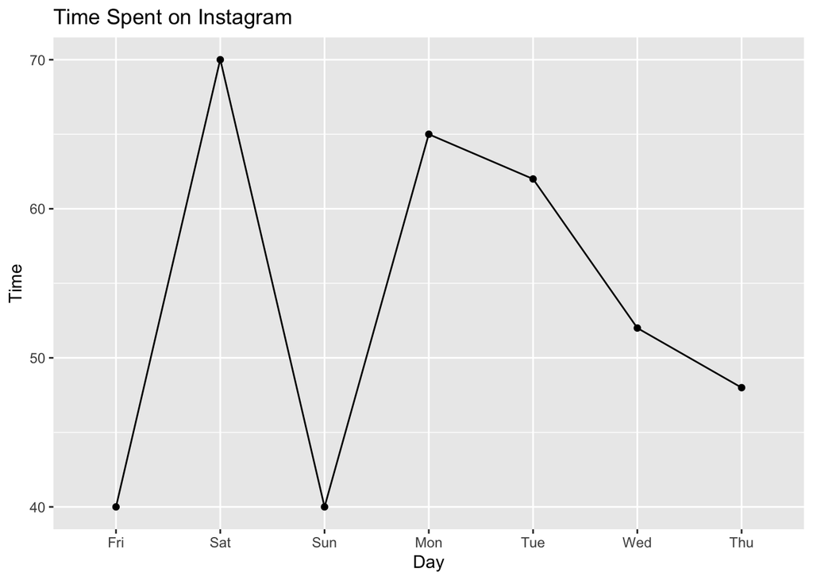

```r
ggplot(data = instagram, aes(x = Day, y = Time,group=1)) + geom_line()+geom_point()+scale_x_discrete(limits=instagram$Day)+labs(title = 'Time Spent on Instagram')
```

I’ve changed to a line graph since variable day is associated with a time period. So I thought that it is better to visualize the timeflow of the average time spent on instagram. Also, I have added the axis and the labels to the y-axis which represents the time in minutes, so that we are able to know the maximum/minimum time spent for corresponding day.

## 3. Cal’s Football Game-by-Game Statistics

```r
games = read.csv(
file = "/Users/kundoongs/Downloads/cal-games.csv",
stringsAsFactors = FALSE,
colClasses = c(
"Date",
"character",
"character",
"numeric",
"numeric",
"numeric",
"numeric"
))
head(games)
```

```
##         date opponent home_away cal_score opp_score duration attendance
## 1 2010-09-04 UC Davis      home        52         3      175      58040
## 2 2010-09-11 Colorado      home        52         7      187      55440
## 3 2010-09-17   Nevada      away        31        52      199      28809
## 4 2010-09-25  Arizona      away         9        10      183      51906
## 5 2010-10-09     UCLA      home        35         7      184      61664
## 6 2010-10-16      USC      away        14        48      187      72386
```

#### a) Does playing at home give Cal’s football team an advantage over its opponents?

```r
games$difference = games$cal_score - games$opp_score

games$won = ifelse(games$difference >0, 1,0)
games$won = as.logical(games$won)
head(games)
```

```
##         date opponent home_away cal_score opp_score duration attendance
## 1 2010-09-04 UC Davis      home        52         3      175      58040
## 2 2010-09-11 Colorado      home        52         7      187      55440
## 3 2010-09-17   Nevada      away        31        52      199      28809
## 4 2010-09-25  Arizona      away         9        10      183      51906
## 5 2010-10-09     UCLA      home        35         7      184      61664
## 6 2010-10-16      USC      away        14        48      187      72386
##   difference   won
## 1         49  TRUE
## 2         45  TRUE
## 3        -21 FALSE
## 4         -1 FALSE
## 5         28  TRUE
## 6        -34 FALSE
```

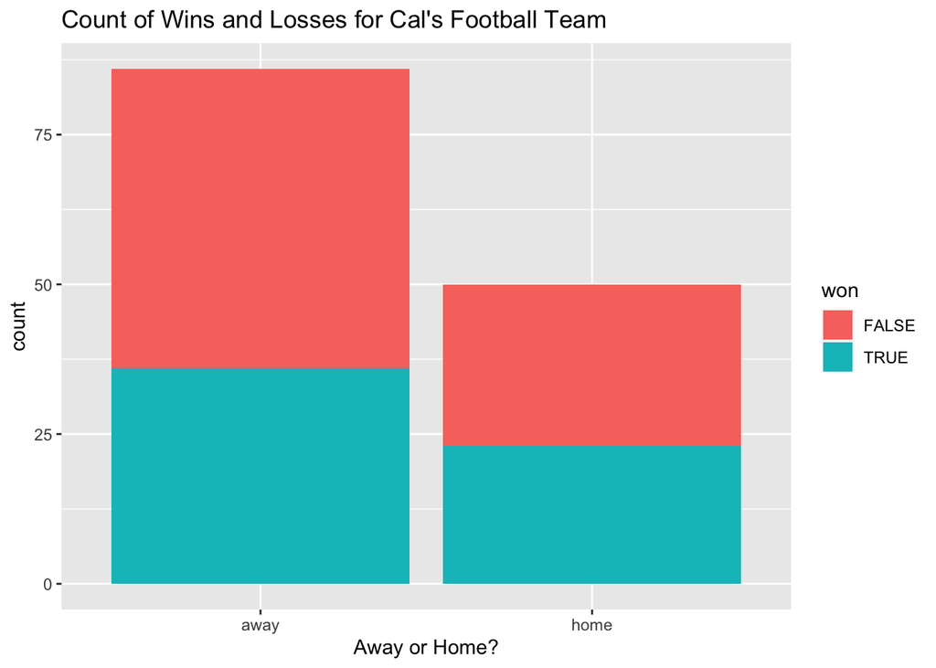

```r
ggplot(games, aes(fill = won,x = home_away))+geom_bar()+labs(title = "Count of Wins and Losses for Cal's Football Team", x= "Away or Home?")
```

It seems like the frequency of win/loss is almost same when they play at cal. Moreover, the frequency of loss is higher when they play at opponent’s. I seems like playing at home does not give Cal’s football team an advantage over its opponents.

#### b) If we focus on those games in September, October, and November, which month(s) tend to be a winning month for Cal? Hint: we recommend using the month() function from package “lubridate” to extract the month of a date-time object

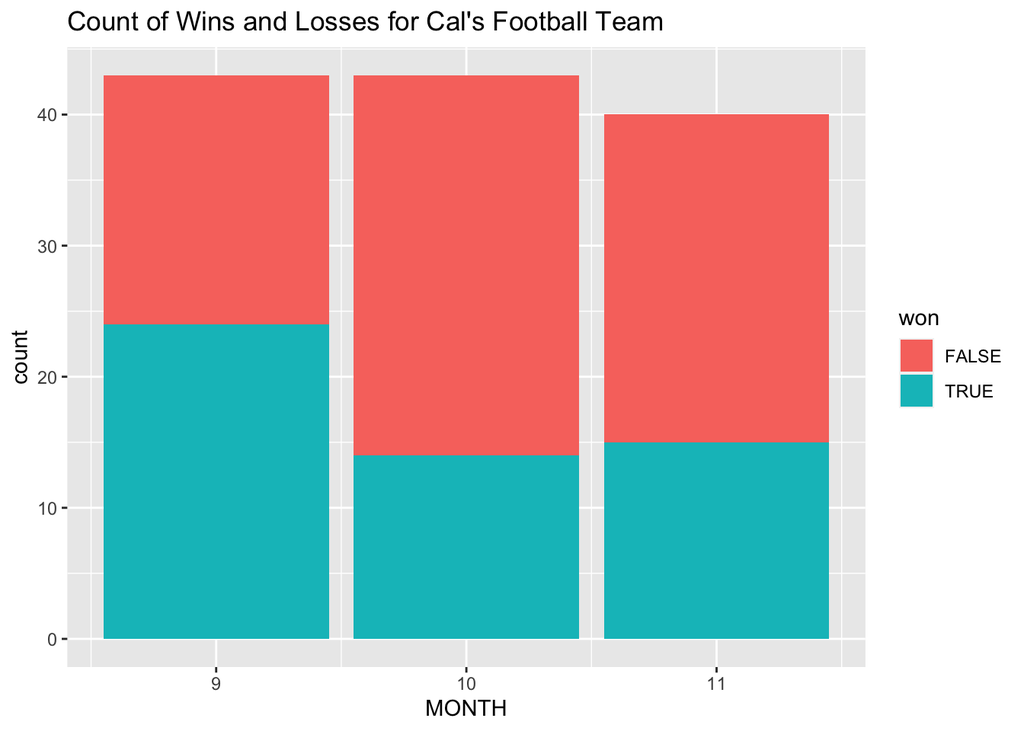

```r
games$MONTH <- lubridate::month(games$date)
only_son = filter(games, MONTH == 9| MONTH == 10| MONTH == 11 )
#only_son
ggplot(only_son, aes(fill = won,x = MONTH))+geom_bar()+labs(title = "Count of Wins and Losses for Cal's Football Team")
```

It is clear that September is the winning month for Cal’s Football Team.

#### c) Create a data visualization that uses the following variables/information

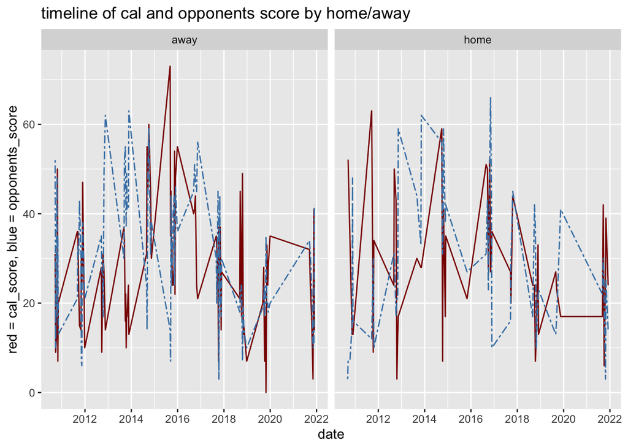

```r
games$year <- lubridate::year(games$date)

filtered <- games[,c("cal_score", "opp_score","date","home_away","date")]

ggplot(filtered, aes(x=date))+
  geom_line(aes(y = cal_score), color = "darkred")+
  geom_line(aes(y = opp_score), color = "steelblue",linetype="twodash") + facet_wrap(~ home_away)+ labs(title = "timeline of cal and opponents score by home/away", y = "red = cal_score, blue = opponents_score")
```